# JHDS Capstone-NLP2

John Shomaker

12/22/2016

### 1. Introduction

This report is the first stage in the Johns Hopkins Data Science Capstone program. The Capstone focuses on the data science of natural language processing (“NLP”), leveraging the entire course’s methodologies and learnings to disect the SwiftKey text dataset. SwiftKey is in the business of mobile applications and technologies, one of which is a feature that predicts type-ahead for mobile texters.

The high-level challenge is to create a practical and reliable word prediction application in shiny, based on a cleaned dataset of text. The source text is a combination of large volumes of blogs, news articles, and Twitter posts (tweets).

This particular document downloads, formats, cleans, and explores the data into a usable format, later used for constructing the predictive model and user application.

### 2. SwiftKey Dataset

We start by downloading the source data from: https://d396qusza40orc.cloudfront.net/dsscapstone/dataset/Coursera-SwiftKey.zip

And, we read the individual blogs, news, and Twitter data into their respective dataframes. The table below is a quick overview of the size, word count, lines, and sentence with the largest number of words.

|  | source | size.MB | lines | words | max.words |
| --- | --- | --- | --- | --- | --- |
| 1 | blogs | 200.4 | 899288 | 37546246 | 6726 |
| 2 | news | 196.3 | 1010242 | 34762395 | 1796 |
| 3 | twitter | 159.4 | 2360148 | 30093410 | 47 |

### 3. Create Samples of US Datasets

```
##           used (Mb) gc trigger  (Mb)  max used  (Mb)
## Ncells 1406009 75.1    7974897 426.0   6275519 335.2
## Vcells 8184620 62.5  111420376 850.1 116859621 891.6
```

```
## [1] "Blog sample (# lines): 180155"
```

```
## [1] "News sample (# lines): 202276"
```

```
## [1] "Twitter sample (# lines): 236851"
```

### 4. Data Cleansing

In many respects, cleansing text is more complex than cleansing numerics. In researching various concepts, it also became clear that libraries and functions to cleanse text are rapidly evolving, so I utilized various libraries. What may have been a 5-line process in a previous library has, in several examples, been simplified to a 1-line command with more intuitive syntax.

```
##            used  (Mb) gc trigger  (Mb)  max used  (Mb)
## Ncells  2198984 117.5    6379917 340.8   7974897 426.0
## Vcells 28174497 215.0   89136300 680.1 116859621 891.6
```

```
##            used (Mb) gc trigger   (Mb)  max used   (Mb)
## Ncells 23086142 1233   33750923 1802.5  33750923 1802.5
## Vcells 66452814  507  107043560  816.7 116859621  891.6
```

### 5. ngram Exploration

The tidytext library is a life-saver: very efficient and very simple for creating ngrams. I took the cleansed corpus, converted to a dataset, created 1-, 2-, 3-, and 4-gram datasets. NOTE: I also found using tidytext obviating the need for TextDocumentMatrix, etc. To generate the ngram frequencies, I simply leveraged ‘dplyr’ (or ‘plyr’ will work) and the ‘count’ function to group the ngrams into their respective frequency tables (akin to a histogram within the dataframe).

I could then use the ngram frequency dataframes to plot frequency for each ngram-type and, for the unigrams, determine how many words are need to cover 50% and 90% of the corpus language. Frequency charts are below.

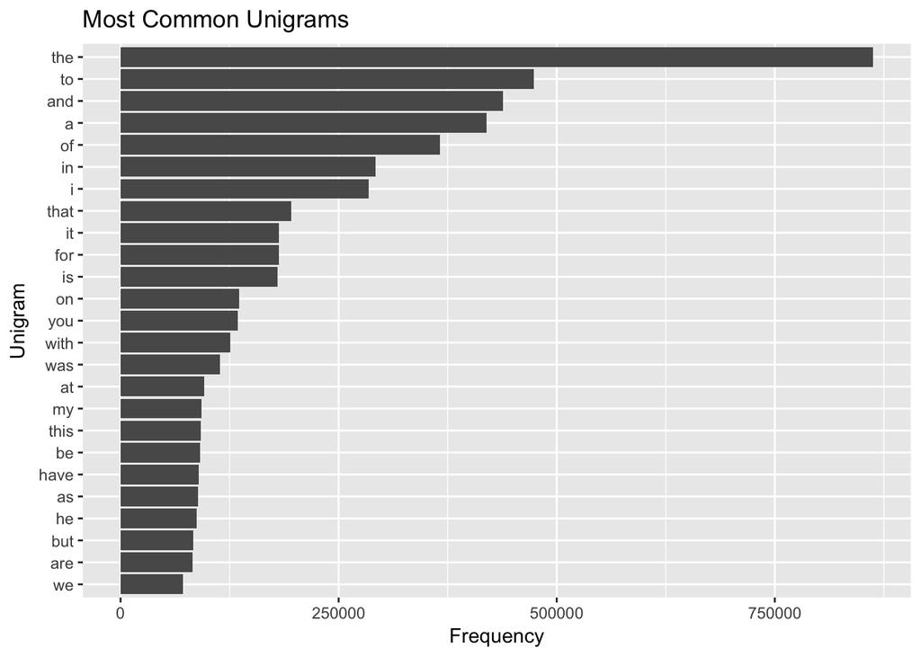

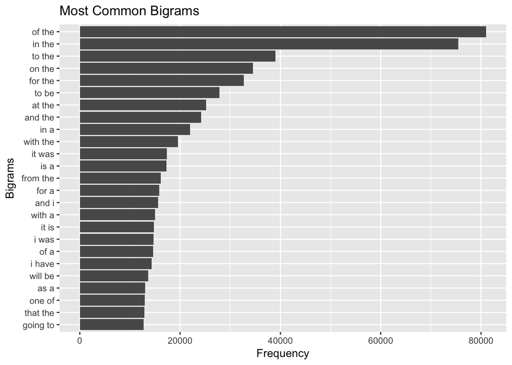

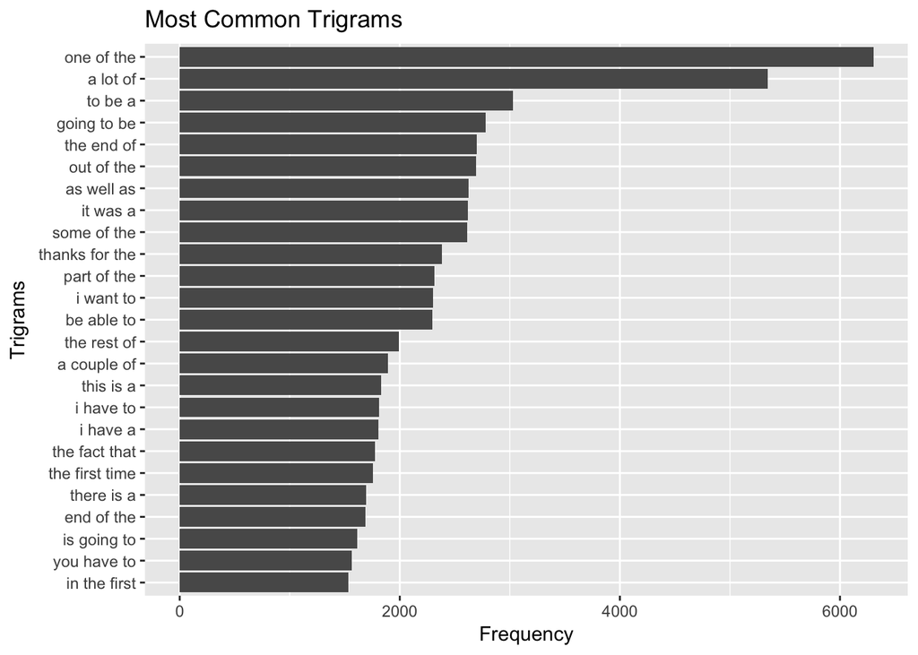

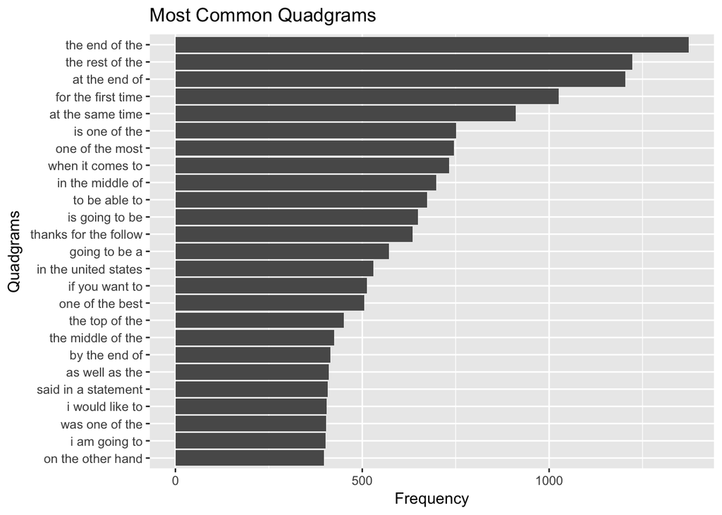

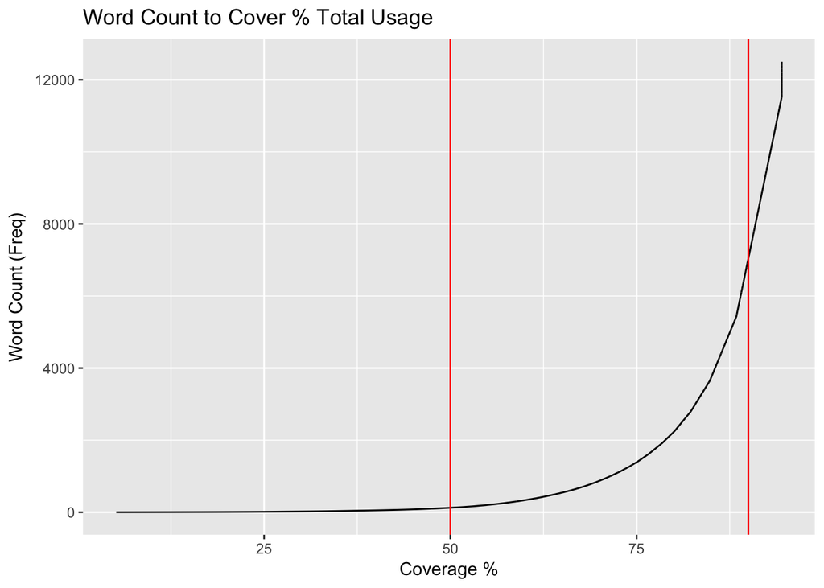

### 6. Saved ngram Data

I then write the ngram data to .txt files to be separately utilized by the prediction modeling phase and analysis.